# Data Science Specialization

March 2021

## Cap Stone project

Goal is to apply the learned skills to an application project covering the following steps:

- **understanding** of the volume and complexity of the datas
- **cleaning** principles for the train set file
- **building** of the model **“Katz Back off”**, with in the usage of **n-grams**, then we will use a Shiny app to demo the tool

The datas are large and are composed of 3 sets related to texts on Blogs, News and Twitter

The following main packages from R were used (among others):  
- **data.table**  
- **quanteda** for text mining. n-grams are stored as .rds files  
- **sqldf** to access quickly to the search results

## An overview of the corpus composed

- The files are selected using a ratio **1/100** (**1%**) and cleaned off their symbols, capital letters, ponctuations, “stopwords”…
- Individual tokens and n-grams (n=2,3,4) are generated and stored as .rds files

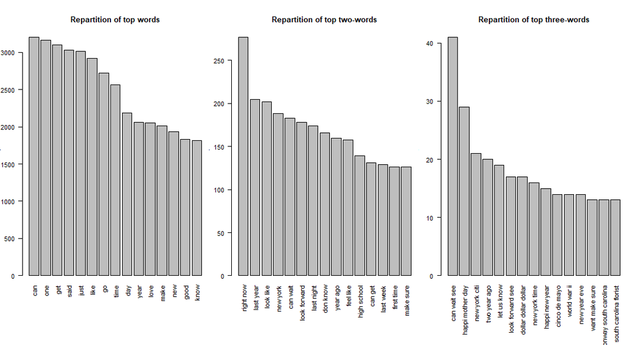

## Strategy for definition of the next word

The strategy being used is the Katz’s back-off model or **n-grams**.  
Here is a 3-grams example extracted from a line:

```
## [1] "vowing to never"    "to never freeze"    "never freeze again"
```

A simple strategy is for example filtering the n-grams with the input of the n-1 words to easily define the outcome with the highest probability for the next word

According to the **Naives Bayes**’s theorem:

P( B | A ) = [ P( B) X P( A | B) ] / P(A)

or said differently

P(this clean water) = P(water | this clean) X P(this clean)

## New word found

Assuming we find a high probability of the fourth word knowing the first 3 words, we display the up-coming fourth word

And continuing, if not found, we use the 3-grams

Until the 2-gram.

If not found, a random selection of the most used word is made (to avoid the same proposal all the times)

## Visualisation on a Shiny application

Here is a snapshot of the application on the right and a wordcloud on the left.  
The algorithm matches in this case with a bigram (2-grams) and proposes “like”.  
You hit **“Predict”** when done your typing

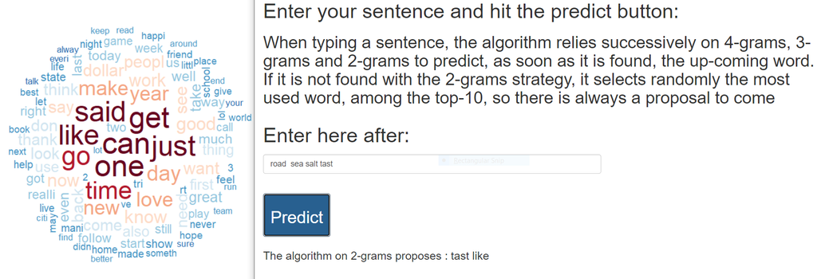

Try it out ! https:\\cochet.shinyapps.io\Final_release\

## A step further with LDA (Quanteda)

LDA stands for **Latent Dirichlet Allocation**  
It belongs to the topic modeling side (bundle of correlated terms)

Convert the trimmed DFM to a topic_models object  
**dfm2topicmodels < convert(mydfm.un.trim, to = “topicmodels”)**  
And the model:  
**lda.model < LDA(dfm2topicmodels, topic.count)**

In which topic, this document(text) is particularly strong:  
text1 7  
text2 20  
text3 10_________________________________Cluster in 20 topics  
text5 16__________________________https:\\rpubs.com\chic\735010  
text6 17

## Future thoughts

txt(“you should write about my personal…”) belongs to topic 19:  
**resp < posterior(lda.model, txt)**

**Far away** from the goal to predict the next word… **BUT**

Topic modeling as an **unsupervised machine learning** can move to…

A **semi supervised model** (applicable let’s say to CCMS databases), the algorithm would define first a set of bags (words) for well known failure cases with expert supervision and then run the model on the complete set

A new DTAC case would be automatically attached to a bag

Not to forget the inputs from IDM monitoring, DTCs…